# Zestaw nr 2

Weronika Duda

31 październik 2023

# Zadanie 1

Tworzę obiekt `lista2` i korzystam z funkcji `lapply()`, żeby policzyć podstawowe statystyki opisowe.

```r
lista2 <- list(dane1 = c(NA, 1:10),
               dane2 = c(-5:5, NA))

lista2
```

```
## $dane1
##  [1] NA  1  2  3  4  5  6  7  8  9 10
##
## $dane2
##  [1] -5 -4 -3 -2 -1  0  1  2  3  4  5 NA
```

```r
lapply(lista2, mean, na.rm = TRUE)
```

```
## $dane1
## [1] 5.5
##
## $dane2
## [1] 0
```

```r
lapply(lista2, sd, na.rm = TRUE)
```

```
## $dane1
## [1] 3.02765
##
## $dane2
## [1] 3.316625
```

```r
lapply(lista2, quantile, na.rm = TRUE)
```

```
## $dane1
##    0%   25%   50%   75%  100%
##  1.00  3.25  5.50  7.75 10.00
##
## $dane2
##   0%  25%  50%  75% 100%
## -5.0 -2.5  0.0  2.5  5.0
```

# Zadanie 2

1. Dla poniższego zestawu danych korzystam z funkcji `sapply()`, aby wyznaczyć maximum i minimum.

```r
lista4 <- list(dane1 = 20:1,
               dane2 = 1:10,
               dane3 = 1:5)

lista4
```

```
## $dane1
##  [1] 20 19 18 17 16 15 14 13 12 11 10  9  8  7  6  5  4  3  2  1
##
## $dane2
##  [1]  1  2  3  4  5  6  7  8  9 10
##
## $dane3
## [1] 1 2 3 4 5
```

```r
sapply(lista4, max)
```

```
## dane1 dane2 dane3
##    20    10     5
```

```r
sapply(lista4, min)
```

```
## dane1 dane2 dane3
##     1     1     1
```

```r
typeof(lista4)
```

```
## [1] "list"
```

```r
is.array(lista4)
```

```
## [1] FALSE
```

```r
is.vector(lista4)
```

```
## [1] TRUE
```

*Wniosek:* Funkcja `sapply()`wykonuje pętlę po liście z funkcją weryfikowaną dla każdego elementu listy, ale stara się uprościć wynik. Funkcja `lapply()` zwraca listę wyników, zachowując oryginalną strukturę.

2. Buduję funkcję mierzącą współczynnik zmienności i testuję go dla przykładowych wartości.

$V = \frac{sd}{mean}$

```r
wspolczynnik_zmiennosci <- function(a)
{
return (sd(a)/mean(a))
}

test_a <- c(10000, 200)
wspolczynnik_zmiennosci(test_a)
```

```
## [1] 1.358754
```

```r
lista_proba <-list(dane1 = 100:1,
               dane2 = 1:10,
               dane3 = 1:50)

sapply(lista_proba, wspolczynnik_zmiennosci)
```

```
##     dane1     dane2     dane3
## 0.5744850 0.5504819 0.5716620
```

*Wniosek:* Da się dla stworzonej funkcji `wspolczynnik_zmiennosci` zastosować funkcję `sapply()`.

# Zadanie 3

Sprawdzam jak działa funkcja `apply()` i czym się różni od wcześniejszych funkcji.

1. Zastosowanie dla obliczania sumy kolumn w macierzy:

```r
matrix_1 <- matrix(1:9, nrow = 3)

suma_kolumn <- apply(matrix_1, 2, sum)
suma_kolumn
```

```
## [1]  6 15 24
```

2. Zastosowanie dla obliczania średniej wierszy w ramce danych:

```r
df_1 <- data.frame(x = c(11, 12, 13),
                 y = c(14, 15, 16))

srednia_wierszy <- apply(df_1, 1, mean)
srednia_wierszy
```

```
## [1] 12.5 13.5 14.5
```

3. Zastosowanie dla znajdowania maksymalnej wartości w każdym wierszu ramki danych:

```r
df_2 <- data.frame(x = c(1, 100, 13), y = c(13, 5, 36))

max_w_wierszach <- apply(df_2, 1, max)
max_w_wierszach
```

```
## [1]  13 100  36
```

*Wniosek:* Funkcja `apply()` różni się od `sapply()` czy `lapply()`, głównie tym, że pozwala na wykonywanie operacji na całych wierszach czy kolumnach macierzy lub ramki danych, a nie na pojedynczych elementach.

# Zadanie 4

- Oglądam zestaw danych `mtcars`.

```r
mtcars
```

|  | mpg | cyl | disp | hp | drat | wt | qsec | vs | am | gear | carb |
| --- | --- | --- | --- | --- | --- | --- | --- | --- | --- | --- | --- |
| Mazda RX4 | 21.0 | 6 | 160.0 | 110 | 3.90 | 2.620 | 16.46 | 0 | 1 | 4 | 4 |
| Mazda RX4 Wag | 21.0 | 6 | 160.0 | 110 | 3.90 | 2.875 | 17.02 | 0 | 1 | 4 | 4 |
| Datsun 710 | 22.8 | 4 | 108.0 | 93 | 3.85 | 2.320 | 18.61 | 1 | 1 | 4 | 1 |
| Hornet 4 Drive | 21.4 | 6 | 258.0 | 110 | 3.08 | 3.215 | 19.44 | 1 | 0 | 3 | 1 |
| Hornet Sportabout | 18.7 | 8 | 360.0 | 175 | 3.15 | 3.440 | 17.02 | 0 | 0 | 3 | 2 |
| Valiant | 18.1 | 6 | 225.0 | 105 | 2.76 | 3.460 | 20.22 | 1 | 0 | 3 | 1 |
| Duster 360 | 14.3 | 8 | 360.0 | 245 | 3.21 | 3.570 | 15.84 | 0 | 0 | 3 | 4 |
| Merc 240D | 24.4 | 4 | 146.7 | 62 | 3.69 | 3.190 | 20.00 | 1 | 0 | 4 | 2 |
| Merc 230 | 22.8 | 4 | 140.8 | 95 | 3.92 | 3.150 | 22.90 | 1 | 0 | 4 | 2 |
| Merc 280 | 19.2 | 6 | 167.6 | 123 | 3.92 | 3.440 | 18.30 | 1 | 0 | 4 | 4 |

[output cut: 22 more lines]

- Z wykorzystaniem funkcji `tapply()`, uzyskuję informację o przeciętnym spalaniu w zależności od liczby cylindrów.

```r
tapply(mtcars$mpg, mtcars$cyl , mean)
```

```
##        4        6        8
## 26.66364 19.74286 15.10000
```

- Rozszerzam analizę przeciętnego poziomu spalania w zależności od liczby cylindrów wyświetlając podstawowe statystyki opisowe.

```r
by(mtcars$mpg, mtcars$cyl, summary)
```

```
## mtcars$cyl: 4
##    Min. 1st Qu.  Median    Mean 3rd Qu.    Max.
##   21.40   22.80   26.00   26.66   30.40   33.90
## ------------------------------------------------------------
## mtcars$cyl: 6
##    Min. 1st Qu.  Median    Mean 3rd Qu.    Max.
##   17.80   18.65   19.70   19.74   21.00   21.40
## ------------------------------------------------------------
## mtcars$cyl: 8
##    Min. 1st Qu.  Median    Mean 3rd Qu.    Max.
##   10.40   14.40   15.20   15.10   16.25   19.20
```

# Zadanie 5

- Oglądam dane przedstawione w ramce `anscombe`oraz wczytuję dane `fgs` z pakietu `MASS`.

```r
anscombe
```

| x1 | x2 | x3 | x4 | y1 | y2 | y3 | y4 |
| --- | --- | --- | --- | --- | --- | --- | --- |
| 10 | 10 | 10 | 8 | 8.04 | 9.14 | 7.46 | 6.58 |
| 8 | 8 | 8 | 8 | 6.95 | 8.14 | 6.77 | 5.76 |
| 13 | 13 | 13 | 8 | 7.58 | 8.74 | 12.74 | 7.71 |
| 9 | 9 | 9 | 8 | 8.81 | 8.77 | 7.11 | 8.84 |
| 11 | 11 | 11 | 8 | 8.33 | 9.26 | 7.81 | 8.47 |
| 14 | 14 | 14 | 8 | 9.96 | 8.10 | 8.84 | 7.04 |
| 6 | 6 | 6 | 8 | 7.24 | 6.13 | 6.08 | 5.25 |
| 4 | 4 | 4 | 19 | 4.26 | 3.10 | 5.39 | 12.50 |
| 12 | 12 | 12 | 8 | 10.84 | 9.13 | 8.15 | 5.56 |
| 7 | 7 | 7 | 8 | 4.82 | 7.26 | 6.42 | 7.91 |

[output cut: 1 more lines]

```r
fgl
```

|  | RI | Na | Mg | Al | Si | K | Ca | Ba | Fe | type |
| --- | --- | --- | --- | --- | --- | --- | --- | --- | --- | --- |
| 1 | 3.01 | 13.64 | 4.49 | 1.10 | 71.78 | 0.06 | 8.75 | 0.00 | 0.00 | WinF |
| 2 | -0.39 | 13.89 | 3.60 | 1.36 | 72.73 | 0.48 | 7.83 | 0.00 | 0.00 | WinF |
| 3 | -1.82 | 13.53 | 3.55 | 1.54 | 72.99 | 0.39 | 7.78 | 0.00 | 0.00 | WinF |
| 4 | -0.34 | 13.21 | 3.69 | 1.29 | 72.61 | 0.57 | 8.22 | 0.00 | 0.00 | WinF |
| 5 | -0.58 | 13.27 | 3.62 | 1.24 | 73.08 | 0.55 | 8.07 | 0.00 | 0.00 | WinF |
| 6 | -2.04 | 12.79 | 3.61 | 1.62 | 72.97 | 0.64 | 8.07 | 0.00 | 0.26 | WinF |
| 7 | -0.57 | 13.30 | 3.60 | 1.14 | 73.09 | 0.58 | 8.17 | 0.00 | 0.00 | WinF |
| 8 | -0.44 | 13.15 | 3.61 | 1.05 | 73.24 | 0.57 | 8.24 | 0.00 | 0.00 | WinF |
| 9 | 1.18 | 14.04 | 3.58 | 1.37 | 72.08 | 0.56 | 8.30 | 0.00 | 0.00 | WinF |
| 10 | -0.45 | 13.00 | 3.60 | 1.36 | 72.99 | 0.57 | 8.40 | 0.00 | 0.11 | WinF |

[output cut: 204 more lines]

- Używam funkcji z rodziny `apply()` do wyznaczenia średnich we wszystkich kolumnach wybranej ramki danych.

```r
srednie_w_kol <- apply(anscombe, 2, mean)
srednie_w_kol
```

```
##       x1       x2       x3       x4       y1       y2       y3       y4
## 9.000000 9.000000 9.000000 9.000000 7.500909 7.500909 7.500000 7.500909
```

- Używam funkcji `str()` do sprawdzenia, które kolumny są numeryczne i powtarzam proces z zad. 1 tylko do tych kolumn.

```r
str(anscombe)
```

```
## 'data.frame':    11 obs. of  8 variables:
##  $ x1: num  10 8 13 9 11 14 6 4 12 7 ...
##  $ x2: num  10 8 13 9 11 14 6 4 12 7 ...
##  $ x3: num  10 8 13 9 11 14 6 4 12 7 ...
##  $ x4: num  8 8 8 8 8 8 8 19 8 8 ...
##  $ y1: num  8.04 6.95 7.58 8.81 8.33 ...
##  $ y2: num  9.14 8.14 8.74 8.77 9.26 8.1 6.13 3.1 9.13 7.26 ...
##  $ y3: num  7.46 6.77 12.74 7.11 7.81 ...
##  $ y4: num  6.58 5.76 7.71 8.84 8.47 7.04 5.25 12.5 5.56 7.91 ...
```

```r
str(fgl)
```

```
## 'data.frame':    214 obs. of  10 variables:
##  $ RI  : num  3.01 -0.39 -1.82 -0.34 -0.58 ...
##  $ Na  : num  13.6 13.9 13.5 13.2 13.3 ...
##  $ Mg  : num  4.49 3.6 3.55 3.69 3.62 3.61 3.6 3.61 3.58 3.6 ...
##  $ Al  : num  1.1 1.36 1.54 1.29 1.24 1.62 1.14 1.05 1.37 1.36 ...
##  $ Si  : num  71.8 72.7 73 72.6 73.1 ...
##  $ K   : num  0.06 0.48 0.39 0.57 0.55 0.64 0.58 0.57 0.56 0.57 ...
##  $ Ca  : num  8.75 7.83 7.78 8.22 8.07 8.07 8.17 8.24 8.3 8.4 ...
##  $ Ba  : num  0 0 0 0 0 0 0 0 0 0 ...
##  $ Fe  : num  0 0 0 0 0 0.26 0 0 0 0.11 ...
##  $ type: Factor w/ 6 levels "WinF","WinNF",..: 1 1 1 1 1 1 1 1 1 1 ...
```

- Sprawdzam typy kolumn.

```r
numeryczne_kolumny <- sapply(anscombe, is.numeric)
numeryczne_kolumny
```

```
##   x1   x2   x3   x4   y1   y2   y3   y4
## TRUE TRUE TRUE TRUE TRUE TRUE TRUE TRUE
```

- Obliczam średnie z kolumn numerycznych.

```r
srednie_numerycznych <- apply(anscombe[, numeryczne_kolumny], 2, mean)

srednie_numerycznych
```

```
##       x1       x2       x3       x4       y1       y2       y3       y4
## 9.000000 9.000000 9.000000 9.000000 7.500909 7.500909 7.500000 7.500909
```

- Używam funkcji z rodziny`apply()` do wyznaczenia mediany we wszystkich kolumnach iloścowych.

```r
mediany <- apply(anscombe[, numeryczne_kolumny], 2, median)
mediany
```

```
##   x1   x2   x3   x4   y1   y2   y3   y4
## 9.00 9.00 9.00 8.00 7.58 8.14 7.11 7.04
```

- Sprawdzam, dla której zmiennej widzimy największą różnicę między średnią a medianą.

```r
roznica_sr_mediana <- srednie_numerycznych - mediany
roznica_sr_mediana
```

```
##          x1          x2          x3          x4          y1          y2
##  0.00000000  0.00000000  0.00000000  1.00000000 -0.07909091 -0.63909091
##          y3          y4
##  0.39000000  0.46090909
```

```r
najwieksza_roznica <- which.max(abs(roznica_sr_mediana))
najwieksza_roznica
```

```
## x4
##  4
```

- Używam funkcji z rodziny `apply()` do obliczenia odchylenia standardowego dla wszystkich kolumn ilościowych.

```r
odchylenia_std <- apply(anscombe[, numeryczne_kolumny], 2, sd)
odchylenia_std
```

```
##       x1       x2       x3       x4       y1       y2       y3       y4
## 3.316625 3.316625 3.316625 3.316625 2.031568 2.031657 2.030424 2.030579
```

- Używam funkcji z rodziny `apply()`współczynnika zmienności dla wszystkich kolumn ilościowych.

```r
wspolczynnik_zmiennosci <- odchylenia_std / srednie_numerycznych
wspolczynnik_zmiennosci
```

```
##        x1        x2        x3        x4        y1        y2        y3        y4
## 0.3685139 0.3685139 0.3685139 0.3685139 0.2708429 0.2708547 0.2707231 0.2707110
```

# Zadanie 6

- Korzystając z funkcji `install.packages()` i `library()` instaluję, a następnie wczytuję pakiety: `tidyr`, `dplyr` oraz `gapminder`.

```r
str(gapminder)
```

```
## tibble [1,704 × 6] (S3: tbl_df/tbl/data.frame)
##  $ country  : Factor w/ 142 levels "Afghanistan",..: 1 1 1 1 1 1 1 1 1 1 ...
##  $ continent: Factor w/ 5 levels "Africa","Americas",..: 3 3 3 3 3 3 3 3 3 3 ...
##  $ year     : int [1:1704] 1952 1957 1962 1967 1972 1977 1982 1987 1992 1997 ...
##  $ lifeExp  : num [1:1704] 28.8 30.3 32 34 36.1 ...
##  $ pop      : int [1:1704] 8425333 9240934 10267083 11537966 13079460 14880372 12881816 13867957 16317921 22227415 ...
##  $ gdpPercap: num [1:1704] 779 821 853 836 740 ...
```

1. Zmieniam nazwy zmiennych: zmienną `year` nazywam rok, a zmienną `gdpPercap` nazywam PKB.

```r
zmieniam_nazwe_rok_PKB <- gapminder %>%
  rename(rok = year) %>%
  rename(PKB = gdpPercap)

zmieniam_nazwe_rok_PKB[1:5,]
```

| country | continent | rok | lifeExp | pop | PKB |
| --- | --- | --- | --- | --- | --- |
| Afghanistan | Asia | 1952 | 28.801 | 8425333 | 779.4453 |
| Afghanistan | Asia | 1957 | 30.332 | 9240934 | 820.8530 |
| Afghanistan | Asia | 1962 | 31.997 | 10267083 | 853.1007 |
| Afghanistan | Asia | 1967 | 34.020 | 11537966 | 836.1971 |
| Afghanistan | Asia | 1972 | 36.088 | 13079460 | 739.9811 |

2. Zmieniam wartości zmiennej `pop` tak, aby ludność była przedstawiona w milionach osób.

```r
kraje_w_mln <- gapminder %>%
  mutate(pop = pop/1000000)

kraje_w_mln[1:5,]
```

| country | continent | year | lifeExp | pop | gdpPercap |
| --- | --- | --- | --- | --- | --- |
| Afghanistan | Asia | 1952 | 28.801 | 8.425333 | 779.4453 |
| Afghanistan | Asia | 1957 | 30.332 | 9.240934 | 820.8530 |
| Afghanistan | Asia | 1962 | 31.997 | 10.267083 | 853.1007 |
| Afghanistan | Asia | 1967 | 34.020 | 11.537966 | 836.1971 |
| Afghanistan | Asia | 1972 | 36.088 | 13.079460 | 739.9811 |

3. Wyświetlam wszystkie kraje afrykańskie, które w roku 1957 miały PKB większe niż 12000$.

```r
kraje_afrykanskie_1957 <- gapminder %>%
  filter(continent == "Africa", year == 1957, gdpPercap > 12000)

kraje_afrykanskie_1957
```

| country | continent | year | lifeExp | pop | gdpPercap |
| --- | --- | --- | --- | --- | --- |

- Instaluję i wczytuję pakiet: `ggplot2`
- Rysuję wykres, który pokazuje ile krajów arykańskich z PKB większym niż 12000$ było w każdym roku badania.

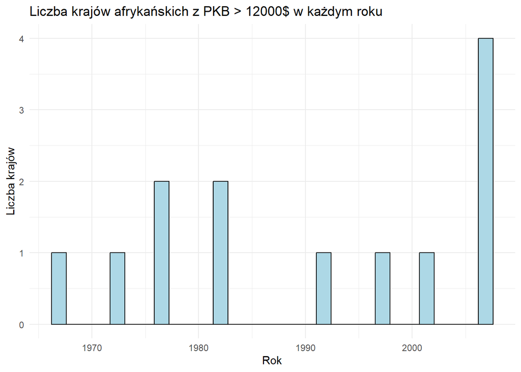

```r
library(ggplot2)

ggplot(data = gapminder %>%
        filter(continent == "Africa" & gdpPercap > 12000)) +
  geom_histogram(mapping = aes(x = year),
                 fill = "lightblue", col = "black",
                 bins = 30) +
  labs(title = "Liczba krajów afrykańskich z PKB > 12000$ w każdym roku",
       x = "Rok", y = "Liczba krajów") +
  theme_minimal()
```

4. Sprawdzam, które kraje spoza Afryki w roku 1962 miały PKB mniejsze od 750$.

```r
kraje_nie_afrykanskie_1962 <- gapminder %>%
  filter(continent != "Africa",
         year == 1962,
         gdpPercap < 750)

kraje_nie_afrykanskie_1962
```

| country | continent | year | lifeExp | pop | gdpPercap |
| --- | --- | --- | --- | --- | --- |
| Bangladesh | Asia | 1962 | 41.21600 | 56839289 | 686.3416 |
| Cambodia | Asia | 1962 | 43.41500 | 6083619 | 496.9136 |
| China | Asia | 1962 | 44.50136 | 665770000 | 487.6740 |
| India | Asia | 1962 | 43.60500 | 454000000 | 658.3472 |
| Myanmar | Asia | 1962 | 45.10800 | 23634436 | 388.0000 |
| Nepal | Asia | 1962 | 39.39300 | 10332057 | 652.3969 |

5. Na przykładzie lat 1952, 1977 i 2002 sprawdzam, ile wynosiła przeciętna długość życia w Polsce i Ameryce.

```r
przecietna_dl_zycia_PL <- gapminder %>%
  filter(country == "Poland", year %in% c(1952, 1977, 2002)) %>%
  select(year, lifeExp)

przecietna_dl_zycia_PL
```

| year | lifeExp |
| --- | --- |
| 1952 | 61.31 |
| 1977 | 70.67 |
| 2002 | 74.67 |

```r
przecietna_dl_zycia_Ameryki <- gapminder %>%
    filter(continent == "Americas" , year %in% c(1952, 1977, 2002)) %>%
    select(country, year, lifeExp)

head(przecietna_dl_zycia_Ameryki)
```

| country | year | lifeExp |
| --- | --- | --- |
| Argentina | 1952 | 62.485 |
| Argentina | 1977 | 68.481 |
| Argentina | 2002 | 74.340 |
| Bolivia | 1952 | 40.414 |
| Bolivia | 1977 | 50.023 |
| Bolivia | 2002 | 63.883 |

- Sprawdzam, w których krajach obu Ameryk była ona większa niż w Polsce.

```r
dane_pl_ameryki <- przecietna_dl_zycia_PL %>%
  full_join(przecietna_dl_zycia_Ameryki, by = c("year"))

kraje_wieksza_dlugosc <- dane_pl_ameryki %>%
  filter(lifeExp.x < lifeExp.y) %>%
  select(year, lifeExp.x, country, lifeExp.y) %>%
  rename(Rok = year,
         DlugoscZyciaPolska = lifeExp.x,
         KrajAmeryki = country,
         DlugoscZyciaAmeryka = lifeExp.y)

kraje_wieksza_dlugosc
```

| Rok | DlugoscZyciaPolska | KrajAmeryki | DlugoscZyciaAmeryka |
| --- | --- | --- | --- |
| 1952 | 61.31 | Argentina | 62.485 |
| 1952 | 61.31 | Canada | 68.750 |
| 1952 | 61.31 | Paraguay | 62.649 |
| 1952 | 61.31 | Puerto Rico | 64.280 |
| 1952 | 61.31 | United States | 68.440 |
| 1952 | 61.31 | Uruguay | 66.071 |
| 1977 | 70.67 | Canada | 74.210 |
| 1977 | 70.67 | Costa Rica | 70.750 |
| 1977 | 70.67 | Cuba | 72.649 |
| 1977 | 70.67 | Puerto Rico | 73.440 |

[output cut: 10 more lines]

**Wnioski:**

- Przez lata obserwowany jest systematyczny wzrost średniej oczekiwanej długości życia w Polsce oraz w innych krajach, które były uwzględnione w analizie.
- Kraje takie jak Portoryko, Stany Zjednoczone i Kanada regularnie pojawiają się w zestawieniu z wyższymi wartościami oczekiwanej długości życia niż Polska w badanych latach.
- Meksyk i Chile pojawiają się w zestawieniu dopiero w roku 2002. To może sugerować, że te kraje stosunkowo niedawno osiągnęły wzrost ekonomiczny i społeczny, który przyczynił się do wydłużenia oczekiwanej długości życia mieszkańców.
6. Wyznaczam podstawowe statystyki opisowe dot. wielkości populacji na różnych kontynentach w roku 2007 z wykorzystaniem funkcji `group_by()` i `summarize()`.

```r
populacja_2007 <- gapminder %>%
  filter(year == 2007) %>%
  group_by(continent) %>%
  summarize(dl_zycia = mean(lifeExp) ,
            max_pop = max(pop) ,
            min_gdpPercap = min(gdpPercap),
            sd_pop = sd(pop),)

populacja_2007
```

| continent | dl_zycia | max_pop | min_gdpPercap | sd_pop |
| --- | --- | --- | --- | --- |
| Africa | 54.80604 | 135031164 | 277.5519 | 24917726 |
| Americas | 73.60812 | 301139947 | 1201.6372 | 68833781 |
| Asia | 70.72848 | 1318683096 | 944.0000 | 289673399 |
| Europe | 77.64860 | 82400996 | 5937.0295 | 23624744 |
| Oceania | 80.71950 | 20434176 | 25185.0091 | 11538855 |

7. Wśród krajów o PKB niższym od 5000$ (rozważam dane za rok 1977), wyznaczam po trzy kraje z Afryki, Europy i Azji, w których spodziewana długość życia jest największa.

```r
kraje_LifeExp <- gapminder %>%
  filter( year == 1977, gdpPercap < 5000) %>%
  group_by(continent) %>%
  top_n(3, wt = lifeExp) %>%
  arrange(continent, desc(lifeExp))

kraje_LifeExp
```

| country | continent | year | lifeExp | pop | gdpPercap |
| --- | --- | --- | --- | --- | --- |
| Reunion | Africa | 1977 | 67.064 | 492095 | 4319.804 |
| Mauritius | Africa | 1977 | 64.930 | 913025 | 3710.983 |
| Tunisia | Africa | 1977 | 59.837 | 6005061 | 3120.877 |
| Chile | Americas | 1977 | 67.052 | 10599793 | 4756.764 |
| Paraguay | Americas | 1977 | 66.353 | 2984494 | 3248.373 |
| Colombia | Americas | 1977 | 63.837 | 25094412 | 3815.808 |
| Korea, Dem. Rep. | Asia | 1977 | 67.159 | 16325320 | 4106.301 |
| Sri Lanka | Asia | 1977 | 65.949 | 14116836 | 1348.776 |
| Malaysia | Asia | 1977 | 65.256 | 12845381 | 3827.922 |
| Bosnia and Herzegovina | Europe | 1977 | 69.860 | 4086000 | 3528.481 |

[output cut: 2 more lines]

8. Tworzę wektory krajów RWPG i UE. Następnie wczytuję dane z 1987 roku oraz dodaję zmienną `system`, która przyjmuje jedną z trzech wartości: “RWPG” dla krajów RWPG, “UE” dla krajów Unii Europejskiej i “Inne” dla pozostałych krajów.
- Do wyfiltrowania krajów europejskich w roku 1987 korzystam z funkcji `subset()`, która służy do wybierania podzbiorów danych z ramki danych na podstawie warunków.

```r
library(gapminder)

kraje_rwpg <- c("Poland", "Hungary", "Bulgaria", "Slovak Republic",
                "Czech Republic", "Albania", "Mongolia", "China", "Korea, Rep.")

kraje_ue <- c("Germany", "Austria", "Belgium", "Denmark", "Spain", "France",
              "Greece", "Ireland", "Italy", "Luxembourg", "Netherlands", "Portugal")

dane_1987 <- subset(gapminder, year == 1987 & continent == "Europe")

dane_1987$system <- ifelse(dane_1987$country %in% kraje_rwpg, "RWPG",
                            ifelse(dane_1987$country %in% kraje_ue, "UE", "Inne"))

head(dane_1987)
```

| country | continent | year | lifeExp | pop | gdpPercap | system |
| --- | --- | --- | --- | --- | --- | --- |
| Albania | Europe | 1987 | 72.00 | 3075321 | 3738.933 | RWPG |
| Austria | Europe | 1987 | 74.94 | 7578903 | 23687.826 | UE |
| Belgium | Europe | 1987 | 75.35 | 9870200 | 22525.563 | UE |
| Bosnia and Herzegovina | Europe | 1987 | 71.14 | 4338977 | 4314.115 | Inne |
| Bulgaria | Europe | 1987 | 71.34 | 8971958 | 8239.855 | RWPG |
| Croatia | Europe | 1987 | 71.52 | 4484310 | 13822.584 | Inne |

- Obliczam podstawowe statystki opisowe dla każdej kategorii kraju (według jego systemu).

```r
statystyki_opisowe_zad6 <- dane_1987 %>%
  group_by(system) %>%
  summarize(
    srednia_pop = mean(pop),
    srednie_lifeExp = mean(lifeExp),
    srednie_PKB = mean(gdpPercap),
    odchylenie_standardowe_pop = sd(pop),
    Q1 = quantile(lifeExp, 0.25),
    Q3 = quantile(lifeExp, 0.75)
  )

statystyki_opisowe_zad6
```

| system | srednia_pop | srednie_lifeExp | srednie_PKB | odchylenie_standardowe_pop | Q1 | Q3 |
| --- | --- | --- | --- | --- | --- | --- |
| Inne | 13657895 | 73.16831 | 18026.35 | 19188359 | 71.2180 | 75.890 |
| RWPG | 12651941 | 71.09333 | 10399.22 | 12648141 | 71.0050 | 71.520 |
| UE | 26329990 | 75.59245 | 19971.95 | 26163734 | 74.8235 | 76.545 |

# Zadanie 7

Na jednym wykresie liniowym rysuję, jak w rozważanych latach zmieniała się oczekiwana długość życia w Japonii, Chinach i Indonezji.

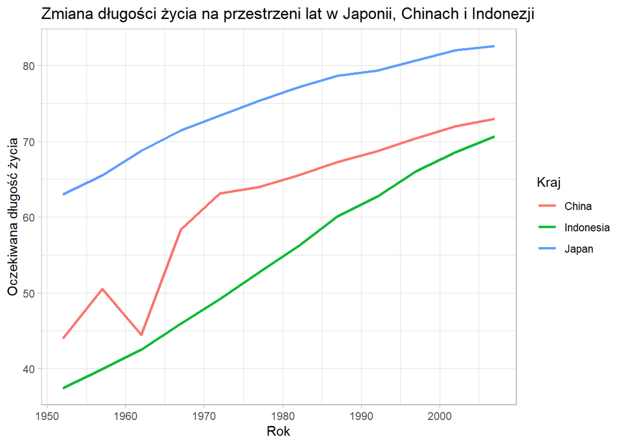

```r
gapminder %>%
  filter(country %in% c("Japan", "China", "Indonesia")) %>%
  ggplot() +
  geom_line(mapping = aes(x = year, y = lifeExp, col = country), linewidth = 1) +
  labs(
    title = "Zmiana długości życia na przestrzeni lat w Japonii, Chinach i Indonezji ",
    x = "Rok", y = "Oczekiwana długość życia", color = "Kraj") +
  theme_light()
```

# Zadanie 8

- Funkcja `set.seed()` służy do inicjalizacji generatora liczb pseudolosowych. Funkcja ta jest używana, by kontrolować generowanie tych samych “losowych” liczb w przyszłości. Nastepnie korzystając z funkcji takich jak np. `sample()`, uzyskuje się powtarzalne wyniki w symulacjach.
- Z wykorzystaniem funkcji `sample()` symuluję rzut kostką sześcienną. Rzut wykonywany będzie: 2, 10, 50, 100 i 1000 razy.

```r
set.seed(123)

liczba_rzutow_kostka <- c(2, 10, 50, 100, 1000)

wyniki_symulacji <- lapply(liczba_rzutow_kostka,
                           function(n) sample(1:6, n, replace = TRUE))
```

- Korzystam z funkcji `table()` do zliczania, ile razy każda liczba wypadła w tym doświadczeniu.

```r
tablice_wynikow <- lapply(wyniki_symulacji, table)

tablice_wynikow
```

```
## [[1]]
##
## 3 6
## 1 1
##
## [[2]]
##
## 1 2 3 4 5 6
## 1 2 2 1 1 3
##
## [[3]]
##
##  1  2  3  4  5  6
## 12  8  9  7 10  4
##
## [[4]]
##
##  1  2  3  4  5  6
## 13 13 17 17 11 29
##
## [[5]]
##
##   1   2   3   4   5   6
## 172 175 161 153 174 165
```

- Wykorzystuję funkcję `mean()`, by wyznaczyć średnią liczbę oczek w doświadczeniu.

```r
srednie_wyniki_rzutow <- sapply(wyniki_symulacji, function(wyniki) mean(wyniki))
round(srednie_wyniki_rzutow)
```

```
## [1] 4 4 3 4 3
```

- **Symulacja Monte Carlo** - technika numeryczna wykorzystywana do modelowania i analizy problemów poprzez generowanie losowych próbek z rozkładów prawdopodobieństwa.

```r
symulacja <- function() {
  play_off <- sum(sample(c(0,1), 7,
                       replace = TRUE,
                       prob = c(0.35,0.65)))
  return(play_off)
}

wyniki_rywalizacji <- replicate(10000, symulacja())

liczba_zwyciestw <- sum(wyniki_rywalizacji >= 4)
cat("Liczba zwycięstw:", liczba_zwyciestw, "\n")
```

```
## Liczba zwycięstw: 8017
```

```r
czestosc_wygranych <- (liczba_zwyciestw / 10000)
procentowo_czestosc <- czestosc_wygranych * 100

wynik_w_procentach <- paste(procentowo_czestosc, "%")
cat("Częstotość zwycięstw:", wynik_w_procentach, "\n")
```

```
## Częstotość zwycięstw: 80.17 %
```

# Zadanie 9

- Analizuję dane `mammals` oraz `Animals2`pod kątem różnic między zwięrzetami schrakteryzowanymi w obu zestawach danych.

[output not shown]

[output not shown]

```r
head(mammals)
```

|  | body | brain |
| --- | --- | --- |
| Arctic fox | 3.385 | 44.5 |
| Owl monkey | 0.480 | 15.5 |
| Mountain beaver | 1.350 | 8.1 |
| Cow | 465.000 | 423.0 |
| Grey wolf | 36.330 | 119.5 |
| Goat | 27.660 | 115.0 |

```r
head(Animals2)
```

|  | body | brain |
| --- | --- | --- |
| Mountain beaver | 1.35 | 8.1 |
| Cow | 465.00 | 423.0 |
| Grey wolf | 36.33 | 119.5 |
| Goat | 27.66 | 115.0 |
| Guinea pig | 1.04 | 5.5 |
| Dipliodocus | 11700.00 | 50.0 |

- Tworzę wektor `zwierzaki` przechowujący nazwy gatunków zwierząt powtarzających się w obu ramkach danych.

```r
zwierzaki <- intersect(rownames(mammals), rownames(Animals2))

zwierzaki
```

```
##  [1] "Owl monkey"                "Mountain beaver"
##  [3] "Cow"                       "Grey wolf"
##  [5] "Goat"                      "Roe deer"
##  [7] "Guinea pig"                "Verbet"
##  [9] "Chinchilla"                "Ground squirrel"
## [11] "African giant pouched rat" "Lesser short-tailed shrew"
## [13] "Star-nosed mole"           "Nine-banded armadillo"
## [15] "Tree hyrax"                "N.A. opossum"
## [17] "Asian elephant"            "Big brown bat"
## [19] "Donkey"                    "Horse"
## [21] "European hedgehog"         "Cat"
## [23] "Galago"                    "Genet"
## [25] "Giraffe"                   "Gorilla"
## [27] "Grey seal"                 "Rock hyrax-a"
## [29] "Human"                     "African elephant"
## [31] "Water opossum"             "Rhesus monkey"
## [33] "Kangaroo"                  "Yellow-bellied marmot"
## [35] "Golden hamster"            "Mouse"
## [37] "Little brown bat"          "Slow loris"
## [39] "Okapi"                     "Rabbit"
## [41] "Sheep"                     "Jaguar"
## [43] "Chimpanzee"                "Baboon"
## [45] "Desert hedgehog"           "Giant armadillo"
## [47] "Rock hyrax-b"              "Raccoon"
## [49] "Rat"                       "E. American mole"
## [51] "Musk shrew"                "Pig"
## [53] "Echidna"                   "Brazilian tapir"
## [55] "Tenrec"                    "Phalanger"
## [57] "Tree shrew"                "Red fox"
```

- Korzystając z funkcji `setdiff()`wyświetlam nazwy zwierząt obecnych w zestawie `mammals`, których nie ma w zestawie `Animals2`.

```r
setdiff(rownames(mammals), rownames(Animals2))
```

```
## [1] "Arctic fox"             "Arctic ground squirrel" "Patas monkey"
## [4] "Mole rat"
```

- Używam funkcji `setdiff()`, aby wyświetlić nazwy zwierząt obecnych w `Animals2`, które nie występują w zestawie `mammals`.

```r
setdiff(rownames(Animals2), rownames(mammals))
```

```
## [1] "Dipliodocus"           "Potar monkey"          "Triceratops"
## [4] "Brachiosaurus"         "Mole"                  "Artic fox"
## [7] "Artic ground squirrel"
```

# Zadanie 10

- Używam funkcji `qnorm()` by wyznaczyć 5% i 95% kwantyl dla rozkładu N(0,1).

```r
qnorm(0.05)
```

```
## [1] -1.644854
```

```r
qnorm(0.95)
```

```
## [1] 1.644854
```

- Używam funkcji `qt()`, by wyznaczyć 5% i 95% kwantyl dla rozkładu t-Studenta. Załadam, że liczba stopni swobody (parametr tego rozkładu) wynosi odpowiednio 1, 5, 10, 30, 50 i 1000.

```r
tStudent <- c(1, 5, 10, 30, 50, 1000)
for (df in tStudent) {
  kwantyl_5 <- qt(0.05, df)
  kwantyl_95 <- qt(0.95, df)
  cat(paste("Stopnie swobody:", df,
            " 5% kwantyl:", kwantyl_5,
            " 95% kwantyl:", kwantyl_95, "\n"))
}
```

```
## Stopnie swobody: 1  5% kwantyl: -6.31375151467504  95% kwantyl: 6.31375151467504
## Stopnie swobody: 5  5% kwantyl: -2.01504837333302  95% kwantyl: 2.01504837333302
## Stopnie swobody: 10  5% kwantyl: -1.81246112281168  95% kwantyl: 1.81246112281168
## Stopnie swobody: 30  5% kwantyl: -1.69726088659396  95% kwantyl: 1.69726088659396
## Stopnie swobody: 50  5% kwantyl: -1.6759050251631  95% kwantyl: 1.6759050251631
## Stopnie swobody: 1000  5% kwantyl: -1.64637881728546  95% kwantyl: 1.64637881728546
```

*Wniosek:* Badając poszczególne wyniki można wywnioskować, że im więcej stopni swobody, tym bardziej rozkład t-Studenta przypomina rozkład normalny, czyli przybliżenie rozkładu normalnego staje się coraz dokładniejsze wraz zezwiększaniem liczby stopni swobody.